# Sensitivity of song diversification and evolution inference

### For MAFFT-agnostic

Assuming a relaxed clock and sampling all fossil records. We can only use CCE HC1 and SUR for new vs old and BR1 TR1 and SUR for fossils vs no fossils

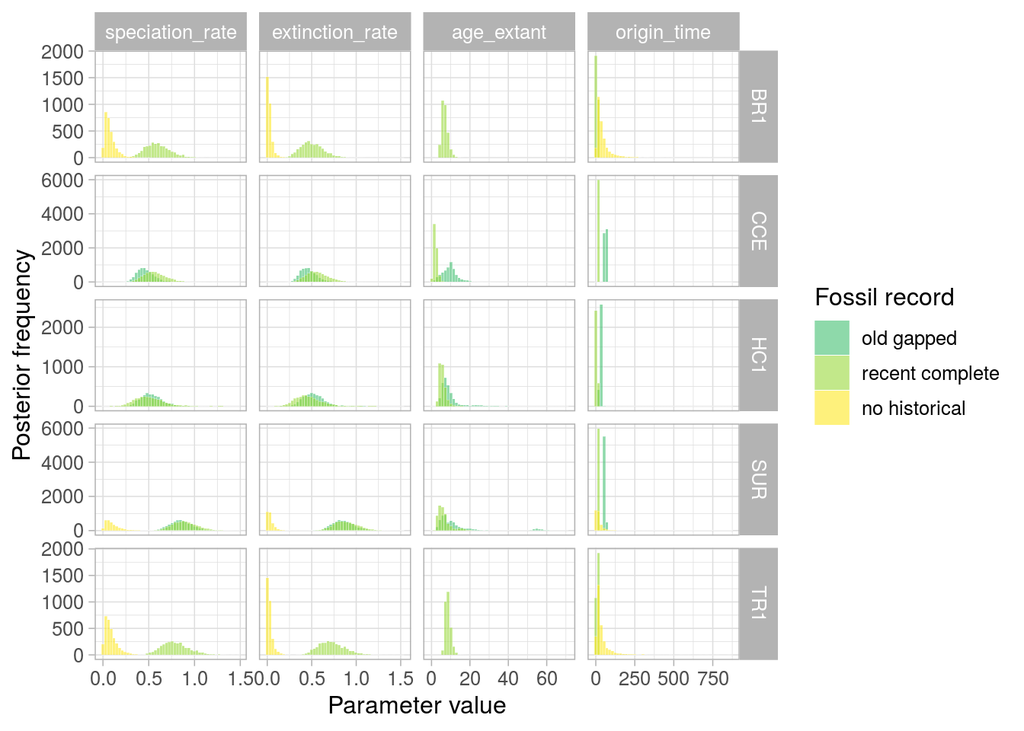

```r
file.ls <- list.files(path=out_fp,pattern=paste0(glob2rx("*all.equal*all*Uexp_*"),"[0-9]{6}.log","|",glob2rx("*all.equal*full.process*Uexp_*"),"[0-9]{6}.log"))

dat_all.equal_record <- data.frame()
for (i in lek) {
  if (i == "SUR") {
    for (j in record) {
      tmp_file <-
        grep(pattern = paste(i, "all.equal", j , sep = "_"), file.ls)
      tmp_data <-
        read.table(paste0(out_fp, file.ls[tmp_file]), header = T)
      if (j == "no.fossils") {
        tmp_data$age_extant <- NA
      }
      tmp_data <- tmp_data[, c("Iteration", div_pars)]
      tmp_data$lek <- i
      tmp_data$record <- j
      dat_all.equal_record <- rbind(dat_all.equal_record, tmp_data)
    }
  } else {
    if (i == "BR1" | i == "TR1") {
      for (j in record[2:3]) {
        tmp_file <-
          grep(pattern = paste(i, "all.equal", j , sep = "_"), file.ls)
        tmp_data <-
          read.table(paste0(out_fp, file.ls[tmp_file]), header = T)
        if (j == "no.fossils") {
          tmp_data$age_extant <- NA
        }
        tmp_data <- tmp_data[, c("Iteration", div_pars)]
        tmp_data$lek <- i
        tmp_data$record <- j
        dat_all.equal_record <- rbind(dat_all.equal_record, tmp_data)
      }
    } else {
      for (j in record[1:2]) {
        tmp_file <-
          grep(pattern = paste(i, "all.equal", j , sep = "_"), file.ls)
        tmp_data <-
          read.table(paste0(out_fp, file.ls[tmp_file]), header = T)
        tmp_data <- tmp_data[, c("Iteration", div_pars)]
        tmp_data$lek <- i
        tmp_data$record <- j
        dat_all.equal_record <- rbind(dat_all.equal_record, tmp_data)
      }
    }
  }
}

plot_dat <- dat_all.equal_record[,c("Iteration","lek", "record", div_pars)]
plot_dat <- pivot_longer(plot_dat, cols = all_of(div_pars), names_to = "par" )

plot_dat$par_s = factor(plot_dat$par, levels = div_pars)
plot_dat$record = factor(plot_dat$record, levels = c("old", "new", "no.fossils"))

p_div_h_record_all.equal <- ggplot(data = plot_dat, aes(x = value, fill = record)) +
  geom_histogram(position = "identity", bins = 50, colour = "white", alpha = 0.6, size =0.05) +
  facet_grid(rows = vars(lek), cols = vars(par_s), scales = "free") +
  theme_light(base_size = 12) +
  scale_fill_manual(values = record_cols, labels = record_labs) +
  labs(x = "Parameter value", y = "Posterior frequency", fill = "Fossil record")

p_div_h_record_all.equal
```

## Sampling strategy of historical records

Are diversification parameters sensitive to consecutive sampling of the same songs

### For PRANK

Assuming a relaxed clock and using old fossils when available

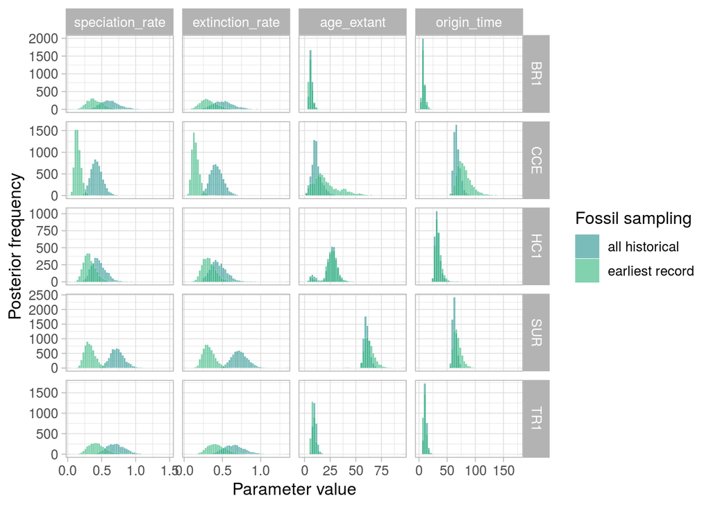

```r
file.ls <- list.files(path=out_fp,pattern=paste0(glob2rx("*prank*Uexp_*"),"[0-9]{6}.log"))

dat_prank_sampling <- data.frame()
for (i in lek) {
  if (i == "BR1" | i == "TR1") {
    for (j in sampling) {
      tmp_file <-
        grep(pattern = paste(i, "prank", "new" , j , sep = "_"), file.ls)
      tmp_data <-
        read.table(paste0(out_fp, file.ls[tmp_file]), header = T)
      tmp_data <- tmp_data[, c("Iteration", div_pars)]
      tmp_data$lek <- i
      tmp_data$sampling <- j
      dat_prank_sampling <- rbind(dat_prank_sampling, tmp_data)
    }
  } else {
    for (j in sampling) {
      tmp_file <-
        grep(pattern = paste(i, "prank", "old", j , sep = "_"), file.ls)
      tmp_data <-
        read.table(paste0(out_fp, file.ls[tmp_file]), header = T)
      tmp_data <- tmp_data[, c("Iteration", div_pars)]
      tmp_data$lek <- i
      tmp_data$sampling <- j
      dat_prank_sampling <- rbind(dat_prank_sampling, tmp_data)
    }
  }
}

plot_dat <- dat_prank_sampling[,c("Iteration","lek", "sampling", div_pars)]
plot_dat <- pivot_longer(plot_dat, cols = all_of(div_pars), names_to = "par" )

plot_dat$par_s = factor(plot_dat$par, levels = div_pars)

p_div_h_sampling_prank <- ggplot(data = plot_dat, aes(x = value, fill = sampling)) +
  geom_histogram(position = "identity", bins = 50, colour = "white", alpha = 0.6, size =0.05) +
  facet_grid(rows = vars(lek), cols = vars(par_s), scales = "free") +
  theme_light(base_size = 12) +
  scale_fill_manual(values = sampling_cols, labels = sampling_labs) +
  labs(x = "Parameter value", y = "Posterior frequency", fill = "Fossil sampling")

p_div_h_sampling_prank
```

### For MAFFT-optimal

Assuming a relaxed clock and using old fossils when available.

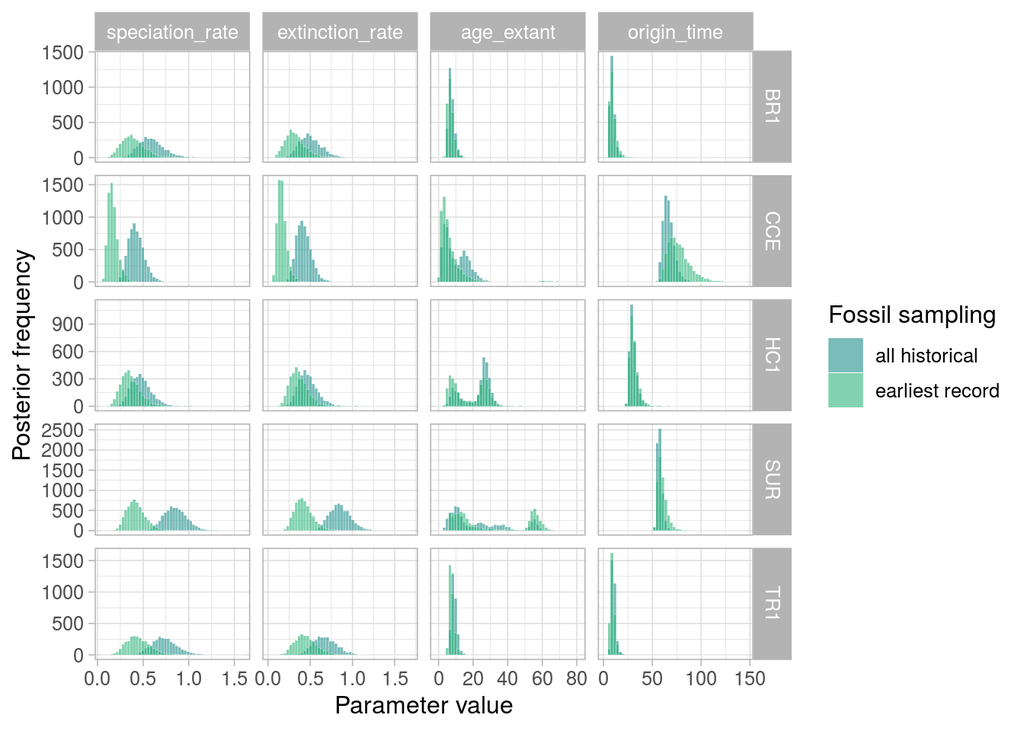

```r
file.ls <- list.files(path=out_fp,pattern=paste0(glob2rx("*optimal*Uexp_*"),"[0-9]{6}.log"))

dat_optimal_sampling <- data.frame()
for (i in lek) {
  if (i == "BR1" | i == "TR1") {
    for (j in sampling) {
      tmp_file <-
        grep(pattern = paste(i, "optimal", "new" , j , sep = "_"), file.ls)
      tmp_data <-
        read.table(paste0(out_fp, file.ls[tmp_file]), header = T)
      tmp_data <- tmp_data[, c("Iteration", div_pars)]
      tmp_data$lek <- i
      tmp_data$sampling <- j
      dat_optimal_sampling <- rbind(dat_optimal_sampling, tmp_data)
    }
  } else {
    for (j in sampling) {
      tmp_file <-
        grep(pattern = paste(i, "optimal", "old", j , sep = "_"), file.ls)
      tmp_data <-
        read.table(paste0(out_fp, file.ls[tmp_file]), header = T)
      tmp_data <- tmp_data[, c("Iteration", div_pars)]
      tmp_data$lek <- i
      tmp_data$sampling <- j
      dat_optimal_sampling <- rbind(dat_optimal_sampling, tmp_data)
    }
  }
}

plot_dat <- dat_optimal_sampling[,c("Iteration","lek", "sampling", div_pars)]
plot_dat <- pivot_longer(plot_dat, cols = all_of(div_pars), names_to = "par" )

plot_dat$par_s = factor(plot_dat$par, levels = div_pars)

p_div_h_sampling_optimal <- ggplot(data = plot_dat, aes(x = value, fill = sampling)) +
  geom_histogram(position = "identity", bins = 50, colour = "white", alpha = 0.6, size =0.05) +
  facet_grid(rows = vars(lek), cols = vars(par_s), scales = "free") +
  theme_light(base_size = 12) +
  scale_fill_manual(values = sampling_cols, labels = sampling_labs) +
  labs(x = "Parameter value", y = "Posterior frequency", fill = "Fossil sampling")
p_div_h_sampling_optimal
```

### For MAFFT-agnostic

Assuming a relaxed clock and using old fossils when available.

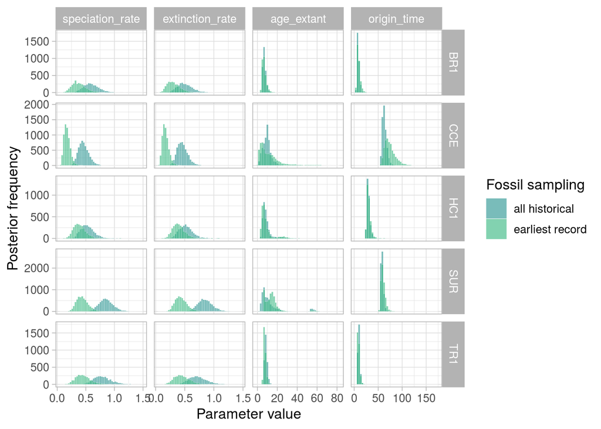

```r
file.ls <- list.files(path=out_fp,pattern=paste0(glob2rx("*all.equal*Uexp_*"),"[0-9]{6}.log"))

dat_all.equal_sampling <- data.frame()
for (i in lek) {
  if (i == "BR1" | i == "TR1") {
    for (j in sampling) {
      tmp_file <-
        grep(pattern = paste(i, "all.equal", "new" , j , sep = "_"), file.ls)
      tmp_data <-
        read.table(paste0(out_fp, file.ls[tmp_file]), header = T)
      tmp_data <- tmp_data[, c("Iteration", div_pars)]
      tmp_data$lek <- i
      tmp_data$sampling <- j
      dat_all.equal_sampling <- rbind(dat_all.equal_sampling, tmp_data)
    }
  } else {
    for (j in sampling) {
      tmp_file <-
        grep(pattern = paste(i, "all.equal", "old", j , sep = "_"), file.ls)
      tmp_data <-
        read.table(paste0(out_fp, file.ls[tmp_file]), header = T)
      tmp_data <- tmp_data[, c("Iteration", div_pars)]
      tmp_data$lek <- i
      tmp_data$sampling <- j
      dat_all.equal_sampling <- rbind(dat_all.equal_sampling, tmp_data)
    }
  }
}

plot_dat <- dat_all.equal_sampling[,c("Iteration","lek", "sampling", div_pars)]
plot_dat <- pivot_longer(plot_dat, cols = all_of(div_pars), names_to = "par" )

plot_dat$par_s = factor(plot_dat$par, levels = div_pars)

p_div_h_sampling_all.equal <- ggplot(data = plot_dat, aes(x = value, fill = sampling)) +
  geom_histogram(position = "identity", bins = 50, colour = "white", alpha = 0.6, size =0.05) +
  facet_grid(rows = vars(lek), cols = vars(par_s), scales = "free") +
  theme_light(base_size = 12) +
  scale_fill_manual(values = sampling_cols, labels = sampling_labs) +
  labs(x = "Parameter value", y = "Posterior frequency", fill = "Fossil sampling")
p_div_h_sampling_all.equal
```

# Song evolution parameters

We want to know if the parameters of the substitution model are sensitive to the alignment strategy.

## Stationary frequencies

Assuming a relaxed clock, sampling all historical records and using old fossils (gapped historical record) when available.

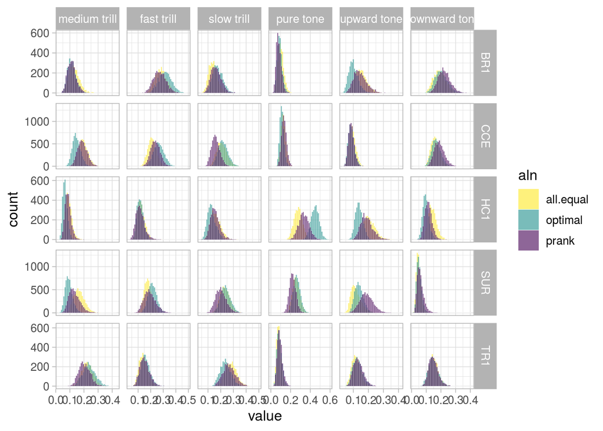

```r
freq_pars <- c("sf.3.", "sf.2.", "sf.5.", "sf.4.", "sf.6.", "sf.1.")

plot_dat <- dat_com[,c("Iteration","lek", "aln", freq_pars)]
plot_dat <- pivot_longer(plot_dat, cols = all_of(freq_pars), names_to = "par" )

plot_dat$par_s = factor(plot_dat$par, levels = freq_pars)
sf.labs <- c("medium trill", "fast trill", "slow trill", "pure tone", "upward tone", "downward tone")
names(sf.labs) <- freq_pars

p_freq_h_aln <- ggplot(data = plot_dat, aes(x = value, fill = aln)) +
  geom_histogram(position = "identity", bins = 50, colour = "white", alpha = 0.6, size =0.05) +
  facet_grid(rows = vars(lek), cols = vars(par_s), scales = "free", labeller = labeller(par_s = sf.labs)) +
  theme_light(base_size = 12) +
  scale_fill_manual(values = aln_cols)

p_freq_h_aln
```